# IE6400 Foundations for Data Analytics Engineering

#### Step 5: Relationship between Features and Target Variable

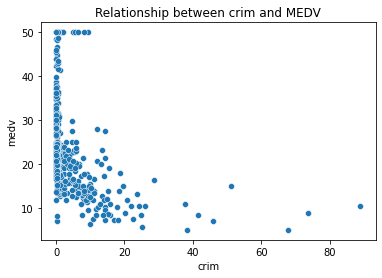

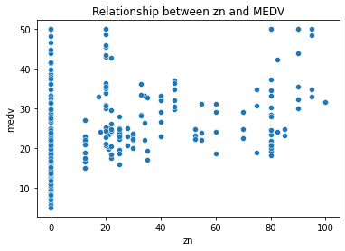

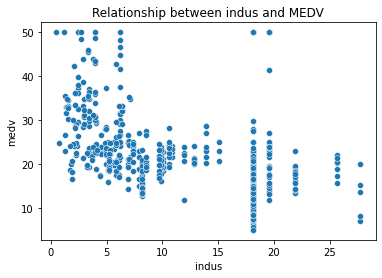

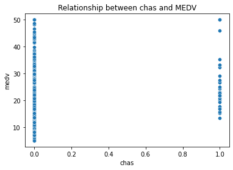

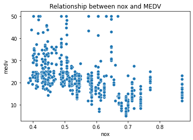

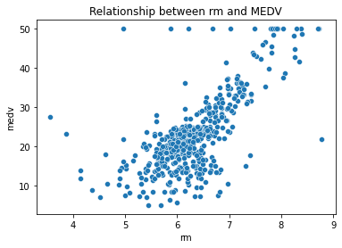

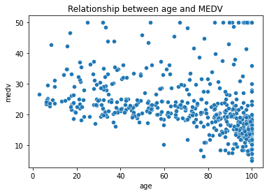

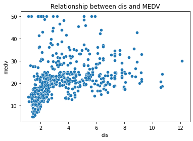

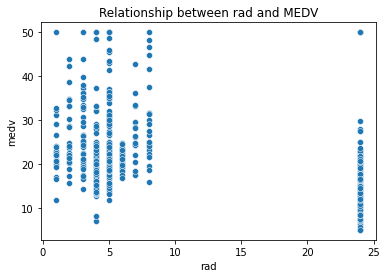

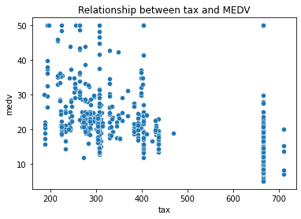

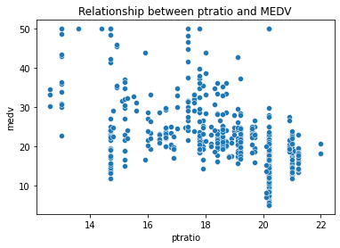

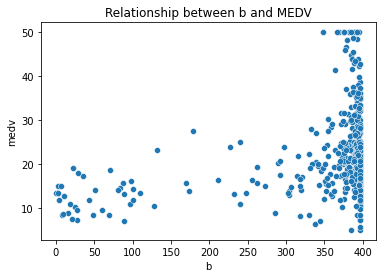

[2 more figures not shown]

```python
# Scatter plots for each feature vs. the target variable
for feature in df.columns:
    plt.figure(figsize=(6, 4))
    sns.scatterplot(data=df, x=feature, y='medv')
    plt.title(f'Relationship between {feature} and MEDV')
    plt.show()
```

#### Interpretation:

- These scatter plots show the relationship between each feature and the target variable (MEDV).
- It helps in understanding how each feature affects the target variable and identifying any patterns or outliers.

#### Step 6: Advanced Visualization - Pair Plot for Selected Features

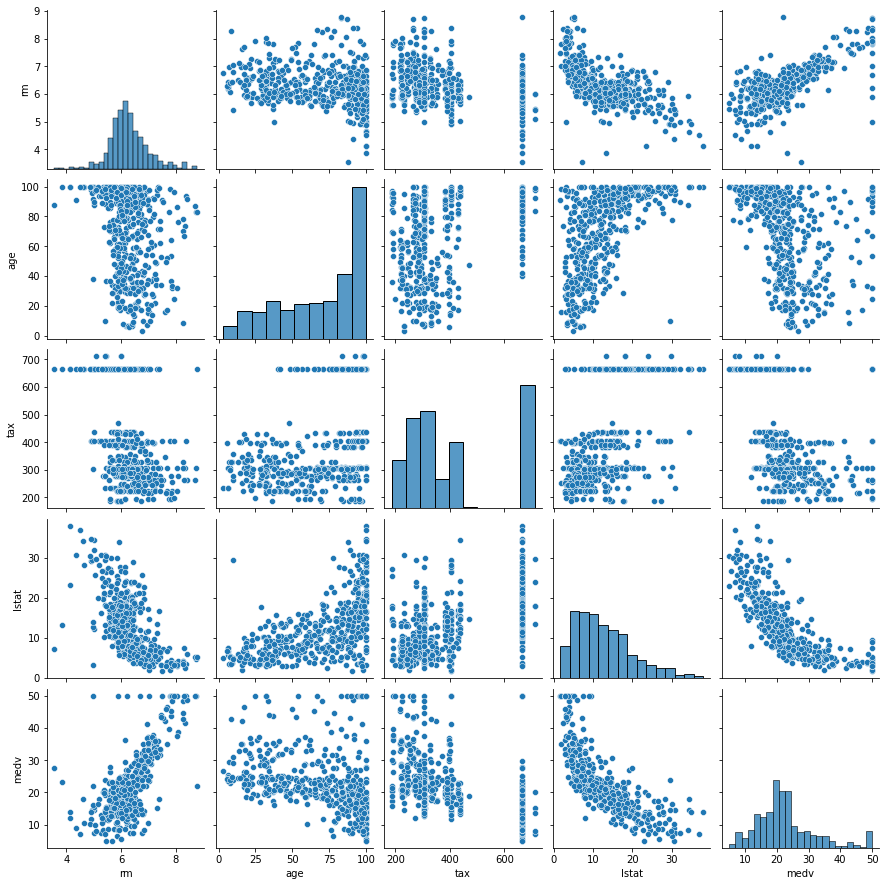

```python
# Pair plot for selected features
selected_features = ['rm', 'age', 'tax', 'lstat', 'medv']
sns.pairplot(df[selected_features])
plt.show()
```

#### Interpretation:

- The pair plot shows scatter plots between pairs of selected features and histograms for individual features.
- It helps in understanding the relationships and distributions of selected features.

#### Conclusion:

- This EDA provides insights into the Boston Housing dataset, including the distribution of the target variable, relationships between features and the target variable, and the correlation between variables. Further analysis can include feature engineering, outlier detection, and machine learning modeling to make predictions based on the features.

Revised Date: October 2nd, 2023